# Communication Data Findings Project

#### Plotting 'bike_share_for_all_trip' feature

```python
df['bike_share_for_all_trip'].value_counts()
```

```
No     153338
Yes     16654
Name: bike_share_for_all_trip, dtype: int64
```

```python
df['bike_share_for_all_trip'].value_counts(normalize=True)
```

```
No     0.902031
Yes    0.097969
Name: bike_share_for_all_trip, dtype: float64
```

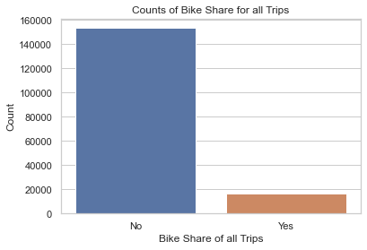

```python
# Plot the distribution of Bike Share for all Trip

# Use seaborn.countplot() function to show the counts of observations in each categorical bin using bars
sb.countplot(data=df, x='bike_share_for_all_trip');

# Use matplotlib.pyplot.title to set a title for the axes.
plt.title('Counts of Bike Share for all Trips');
# Use matplotlib.pyplot.xlabel to set the label for the x-axis.
plt.xlabel('Bike Share of all Trips');
# Use matplotlib.pyplot.ylabel to set the label for the y-axis.
plt.ylabel('Count');
# Use matplotlib.figure() function to control the default spacing of the subplots and the top level container of the subplots,
# and the top level container for all plot elements.
plt.figure(figsize=[ 11.69, 8.27]);
# Use matplotlib.pyplot.show () function to display all open figures.
plt.show();
```

**Observation**

- The value counts of "No", "Yes" off the "Bike Share of all Trip are 153,338, and 16654 respectively.
- However, the percentage of "No" is approximately 90%, and "Yes" is approximately 10% off the "Bike Share of all trip" feature.

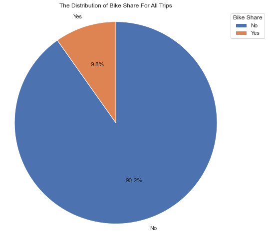

```python
# Plotting the distribution of Bike Share for all Trips

# Use matplotlib.pyplot.pie() function to plot a pie chart
sorted_counts = df['bike_share_for_all_trip'].value_counts()
# Use matplotlib.figure() function to control the default spacing of the subplots and the top level container of the subplots,
# and the top level container for all plot elements.
plt.figure(figsize=[ 11.69, 8.27]);
# Use matplotlib.pyplot.title() to set a title for the axes.
plt.title('The Distribution of Bike Share For All Trips');
# Use matplotlib.pyplot.pie() function to plot a pie chart
plt.pie(sorted_counts, labels = sorted_counts.index, startangle = 90, counterclock = False, autopct='%1.1f%%');
# Use matplotlib.pyplot.axis('square') to create a square plot with equal axes
plt.axis('square');
# Use matplotlib.pyplot.legend() function to place a legend on the axes
plt.legend(title ="Bike Share",loc ="upper left",bbox_to_anchor =(1, 0, 0.5, 1));
# Use matplotlib.pyplot.show() function to display all figures.
plt.show();
```

**Observation**

- The value counts of "No", "Yes" off the "Bike Share of all Trip are 153,338, and 16654 respectively.
- However, the percentage of "No" is approximately 90%, and "Yes" is approximately 10% off the "Bike Share of all trip" feature.

#### Conclusion

**Discuss the distribution(s) of your variable(s) of interest. Were there any unusual points? Did you need to perform any transformations?**

- The mean or average of Trip duration in minutes is 11.73 minutes, maximum value is 1409.13 minutes, and the minimum value is 1.016 minutes.
- The maximum of member ages are 143 years old, it is unusual, so I need to remove the outliers, the member ages greater than 60 years old.
- The plotting of distribution of age reveals that it more concentrated between 25 to 40 years old.
- From the start time hour, the time 8:00 AM and 5:00 PM are the two peak hours which have most bikers.
- It seems to be that the distribution of both start stations and end stations are same.
- The Biker subscribers and customers are representing approximately 90% and 10% percentage, respectively. However, the number of subscriber is 153736 and the number of customer is 16256.
- The male bikers are about three times of female bikers. However, the number of male is 126,311 with percentage of 74%, the number of female is 40,098 with percentage of 24%, and the number of other is 3583 with percentage of 2%.

**Of the features you investigated, were there any unusual distributions? Did you perform any operations on the data to tidy, adjust, or change the form of the data? If so, why did you do this?**

- When investigating the Birth year variables, Birth year is converted by substracting the year from current year 2021 in order to give the distibution for age and better perception.
- Furthermore, start station and end station is plotted in a larger plot so that it gives a better insight regarding traffic of bikes at certain stations.

### Bivariate Exploration

**In the Book "An Introduction to Statistical Learning, with Application in R", By: Gareth James, Danila Witten, Trevor Hastie, Robert Tibshirani", Chapter 3: Linear Regression, and Chapter 4: Classification**

- `Simple Linear Regression` lives up to its name: it is a very straigtforward approach for predicting a quantitative response Y on the basis of a single predictor variable X. It assumes that there is approximately a linear relationship between X and Y.
- However, in statistics, simple linear regression is a linear regression model with a single explanatory variable. Make a comparison of only two quantitative variables. The response variable, y-axis, dependent variable, or target is what you want to predict,while the explanatory variavle, x-axis, independent variable, or predictor is the variable I use to predict the response. A common way to visualize the relationship between two variables in linear regression is using a scatterplot.
- Simple linear regression is a useful approach for predicting a response on the basis of a single predictor variable. However, in practice we often have more than one predictor.In `multiple linear regression`, I will use both the quantitative and categorical x-variables to predict a quantitative response. The way that I add categorical variables into the multiple linear regression models is by using the dummy variables.
- The most common way dummy variables are added is through 1,0 encoding. When I add these dummy variables to the multiple linear regression models, I always drop one of the columns. The column I dropped is called the baseline. Furthermore, the coefficents I obtain from the output of the multiple linear regression models are then an indication of how the encoded levels compare to the baseline level (the dropped level).
- And finally, the `logistic regression` is used to predict categorical variable. However, the linear regression model assumes that the response variable Y is quantitative. But in many situations, the response variable is instead qualitative. Often qualitative variables are referred to as categorical. There are many possible classification techniques, or classifiers, that one might use to predict a qualitative response, which is the `logistic regression`.

**Overview**

- I am trying to figure out the correlation between the duration trip and other features such as: age, start station, end station, user type, and gende in the data.

**Negative Correlation**

- When the scatter plot shows a bunch of dots, where low x-values correspond to high y-values, and high x-values correspond to low y-values. It's fairly obvious to me that I could draw a straight line, starting from around the left-most dot and angling downwards as I move to the right, amongst the plotted data points, and the line would look like a good match to the points. Such a line would have a negative slope, and the plotted data points would all lie on or very close to that drawn line. So there does appear to be a strong correlation here and, because a good-fit line drawn amongst these points would have a negative slope, that correlation is negative.
- In other words, the regression line in a scatter plot showing a negative correlation between the two variables.

**Positive Correlation**

- When the Plot shows a bunch of dots, where low x-values correspond to low y-values, and high x-values correspond to high y-values. It's fairly obvious to me that I could draw a straight line, starting near the left-most dot and angline upwards as I move to the right, amongst the plotted data points, and the line would look like a good match to the points. Such a line would have a positive slope, and the plotted data points would all lie on or very close to that drawn lline. So there does appear to be a strong correlation here and, because the good-fit line drawn amongst these points would have a positive slope, that correlation is positive.
- In other words, the regression line in a scatter plot showing a positive correlation between the two variables.

**No Correlation**

- When the data points are just all over the place, there doesn't appear to be any trend to these data points. I can't conceive of any straight line I could possibly justify drawing across this plot. Maybe additional data points could clear things up but, as things stand, I see no trends at all. With what they've given me, there is no apparent correlation between inputs and outputs.
- On the other hand, when the data points line up very nicely! I can easily draw a horizontal line amongst these dots, and the line would clearly be a good fit to the data. However, the fact that the line would be horizontal means that the input values (that is, the x-values) are irrelevant to the output values (that is, the y-values). I can pick any input value I like, and the output is always going to be right around the same value.
- So there is a definite trend to the data, and there is an excellent good-fit line for it, but that line only says that the input values are irrelevant. If the inputs are irrelevant, then there can't possibly be a correlation between inputs and outputs. That is, the inputs can't possibly have any relationship with the outputs, because the inputs are utterly immaterial to the outputs.

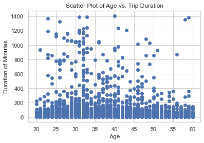

```python
# Use matplotlib.pyplot.scatter() function to apply a scatter plot of y vs. x with varying marker size and /or color
plt.scatter(data=df, x='member_age', y='duration_min');
# Use matplotlib.pyplot.title to set a title for the axes.
plt.title('Scatter Plot of Age vs. Trip Duration');
# Use matplotlib.pyplot.xlabel to set the label for the x-axis.
plt.xlabel('Age');
# Use matplotlib.pyplot.ylabel to set the label for the y-axis.
plt.ylabel('Duration of Minutes');
# Use matplotlib.figure() function to control the default spacing of the subplots and the top level container of the subplots,
# and the top level container for all plot elements.
plt.figure(figsize=[ 11.69, 8.27]);
# Use matplotlib.pyplot.show () function to display all open figures.
plt.show();
```

**Observation**

- The data points are just all over the place, there doesn't appear to be any trend to these data points.
- I can't conceive of any straight line I could possibly justify drawing across this plot.
- Maybe additional data points could clear things up but, as things stand, I see no trends at all.
- Overall, there is no apparent correlation between the two variables.

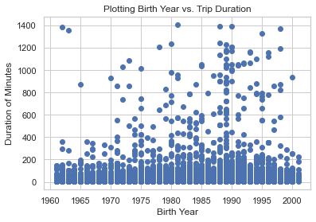

```python
# Use matplotlib.pyplot.scatter() function to apply a scatter plot of y vs. x with varying marker size and /or color
plt.scatter(data=df, x='member_birth_year', y='duration_min');
# Use matplotlib.pyplot.title to set a title for the axes.
plt.title('Plotting Birth Year vs. Trip Duration');
# Use matplotlib.pyplot.xlabel to set the label for the x-axis.
plt.xlabel('Birth Year')
# Use matplotlib.pyplot.ylabel to set the label for the y-axis.
plt.ylabel('Duration of Minutes');
# Use matplotlib.figure() function to control the default spacing of the subplots and the top level container of the subplots,
# and the top level container for all plot elements.
plt.figure(figsize=[ 11.69, 8.27]);
# Use matplotlib.pyplot.show () function to display all open figures.
plt.show();
```

**Observation**

- The data points are just all over the place, there doesn't appear to be any trend to these data points.
- I can't conceive of any straight line I could possibly justify drawing across this plot.
- Maybe additional data points could clear things up but, as things stand, I see no trends at all.
- Overall, there is no apparent correlation between the two variables.

**Resources:**

- Udacity classroom, Lesson 4: Bivariate Exploration of Data, 2.Scatterplot and Correlation.
- Use the documentation [Website](https://matplotlib.org/api/_as_gen/matplotlib.pyplot.scatter.html?highlight=scatter#matplotlib.pyplot.scatter), Use **matplotlib.pyplot.scatter()** function to apply a scatter plot of y vs. x with varying marker size and /or color.
- Use the documentation [Website](https://www.geeksforgeeks.org/matplotlib-pyplot-scatter-in-python/), Matplotlib.pyplot.scatter() in Python.

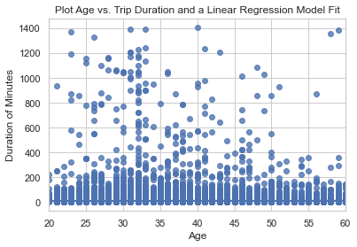

```python
# Use seaborn.regplot() function to plot data and a linear regression model fit
sb.regplot(data=df, x='member_age', y='duration_min');
# Use matplotlib.pyplot.title to set a title for the axes.
plt.title('Plot Age vs. Trip Duration and a Linear Regression Model Fit')
# Use matplotlib.pyplot.xlabel to set the label for the x-axis.
plt.xlabel('Age');
# Use matplotlib.pyplot.ylabel to set the label for the y-axis.
plt.ylabel('Duration of Minutes');
# Use matplotlib.figure() function to control the default spacing of the subplots and the top level container of the subplots,
# and the top level container for all plot elements.
plt.figure(figsize=[ 11.69, 8.27]);
# Use matplotlib.pyplot.show () function to display all open figures.
plt.show();
```

**Observation**

- The data points are just all over the place, there doesn't appear to be any trend to these data points.
- I can't conceive of any straight line I could possibly justify drawing across this plot.
- Maybe additional data points could clear things up but, as things stand, I see no trends at all.
- Overall, there is no apparent correlation between the two variables.

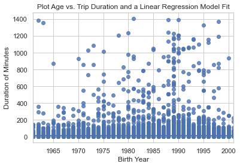

```python
# Use seaborn.regplot() function to plot data and a linear regression model fit
sb.regplot(data=df, x='member_birth_year', y='duration_min');
# Use matplotlib.pyplot.title to set a title for the axes.
plt.title('Plot Age vs. Trip Duration and a Linear Regression Model Fit')
# Use matplotlib.pyplot.xlabel to set the label for the x-axis.
plt.xlabel('Birth Year')
# Use matplotlib.pyplot.ylabel to set the label for the y-axis.
plt.ylabel('Duration of Minutes');
# Use matplotlib.figure() function to control the default spacing of the subplots and the top level container of the subplots,
# and the top level container for all plot elements.
plt.figure(figsize=[ 11.69, 8.27]);
# Use matplotlib.pyplot.show () function to display all open figures.
plt.show();
```

**Observation**

- The data points are just all over the place, there doesn't appear to be any trend to these data points.
- I can't conceive of any straight line I could possibly justify drawing across this plot.
- Maybe additional data points could clear things up but, as things stand, I see no trends at all.
- Overall, there is no apparent correlation between the two variables.

**Resources:**

- Udacity classroom, Lesson 4: Bivariate Exploration of Data, 2.Scatterplots and Correlation.
- Use the documentation [Website](https://seaborn.pydata.org/generated/seaborn.regplot.html), Use **seaborn.regplot()** method to Plot data and a linear regression model fit.
- Use the documentation [Website](https://www.geeksforgeeks.org/python-seaborn-regplot-method/), Python – seaborn.regplot() method.

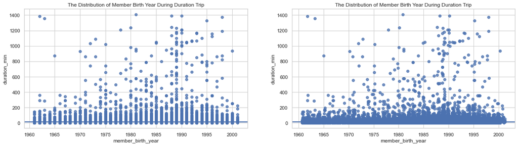

```python
# Resize figure to accommodate two plots
plt.figure(figsize = [20, 5])

# PLOT ON LEFT - SIMPLE SCATTER
plt.subplot(1, 2, 1)
# Use matplotlib.pyplot.title() to set a title for the axes.
plt.title('The Distribution of Member Birth Year During Duration Trip');
sb.regplot(data = df, x = 'member_birth_year', y = 'duration_min', truncate=False);

# PLOT ON RIGHT - SCATTER PLOT WITH JITTER
plt.subplot(1, 2, 2)
# Use matplotlib.pyplot.title() to set a title for the axes.
plt.title('The Distribution of Member Birth Year During Duration Trip');

# In the sb.regplot() function below, the `truncate` argument accepts a boolean.
# If truncate=True, the regression line is bounded by the data limits.
# Else if truncate=False, it extends to the x axis limits.
# The x_jitter will make each x value will be adjusted randomly by +/-0.3
sb.regplot(data = df, x = 'member_birth_year', y = 'duration_min', truncate=False, x_jitter=0.3);
```

**Observation**

- The data points are just all over the place, there doesn't appear to be any trend to these data points.
- I can't conceive of any straight line I could possibly justify drawing across this plot.
- Maybe additional data points could clear things up but, as things stand, I see no trends at all.
- Overall, there is no apparent correlation between the two variables.

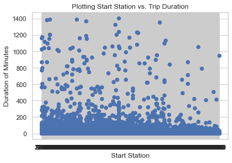

```python
# Use matplotlib.pyplot.scatter() function to apply a scatter plot of y vs. x with varying marker size and /or color
plt.scatter(data=df, x='start_station_id', y='duration_min');
# Use matplotlib.pyplot.title to set a title for the axes.
plt.title('Plotting Start Station vs. Trip Duration');
# Use matplotlib.pyplot.xlabel to set the label for the x-axis.
plt.xlabel('Start Station')
# Use matplotlib.pyplot.ylabel to set the label for the y-axis.
plt.ylabel('Duration of Minutes');
# Use matplotlib.figure() function to control the default spacing of the subplots and the top level container of the subplots,
# and the top level container for all plot elements.
plt.figure(figsize=[ 11.69, 8.27]);
# Use matplotlib.pyplot.show () function to display all open figures.
plt.show();
```

**Observation**

- The data points are just all over the place, there doesn't appear to be any trend to these data points.
- I can't conceive of any straight line I could possibly justify drawing across this plot.
- The data points line up, and I can easily draw a horizontal line amongst these dots. However, the fact that the line would be horizontal means that the x-values are irrelevant to the y-values.
- Overall, there is no apparent correlation between the two variables.

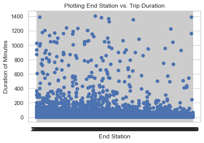

```python
# Use matplotlib.pyplot.scatter() function to apply a scatter plot of y vs. x with varying marker size and /or color
plt.scatter(data=df, x='end_station_id', y='duration_min');
# Use matplotlib.pyplot.title to set a title for the axes.
plt.title('Plotting End Station vs. Trip Duration');
# Use matplotlib.pyplot.xlabel to set the label for the x-axis.
plt.xlabel('End Station')
# Use matplotlib.pyplot.ylabel to set the label for the y-axis.
plt.ylabel('Duration of Minutes');
# Use matplotlib.figure() function to control the default spacing of the subplots and the top level container of the subplots,
# and the top level container for all plot elements.
plt.figure(figsize=[ 11.69, 8.27]);
# Use matplotlib.pyplot.show () function to display all open figures.
plt.show();
```

**Observation**

- The data points are just all over the place, there doesn't appear to be any trend to these data points.
- I can't conceive of any straight line I could possibly justify drawing across this plot.
- The data points line up, and I can easily draw a horizontal line amongst these dots. However, the fact that the line would be horizontal means that the x-values are irrelevant to the y-values.
- Overall, there is no apparent correlation between the two variables.

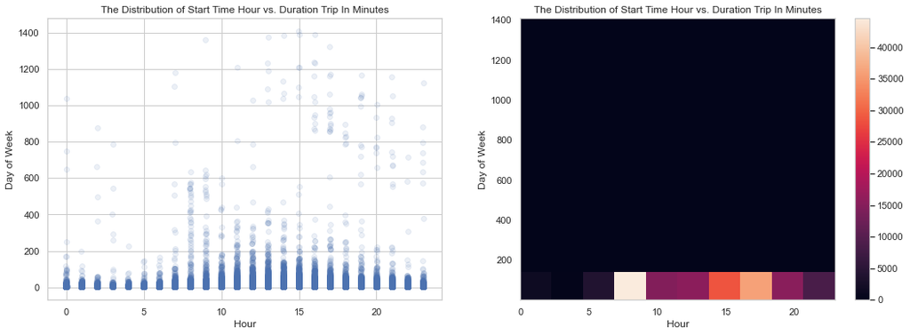

```python
# Use matplotlib.figure() function to control the default spacing of the subplots and the top level container of the subplots,
# and the top level container for all plot elements.
plt.figure(figsize = [18, 6])

# PLOT ON LEFT
# Use matplotlib.pyplot.subplot() function to add a subplot to the current figure.
plt.subplot(1, 2, 1)
# Use matplotlib.pyplot.title() to set a title for the axes.
plt.title('The Distribution of Start Time Hour vs. Duration Trip In Minutes');

# Use seaborn.regplot() function to plot data and a linear regression model fit
sb.regplot(data = df, x = 'start_time_hour', y = 'duration_min', x_jitter=0.04, scatter_kws={'alpha':1/10}, fit_reg=False)
# Use matplotlib.pyplot.xlabel to set the label for the x-axis.
plt.xlabel('Hour')
# Use matplotlib.pyplot.ylabel to set the label for the y-axis.
plt.ylabel('Day of Week');

# PLOT ON RIGHT
# Use matplotlib.pyplot.subplot() function to add a subplot to the current figure.
plt.subplot(1, 2, 2)
# Use matplotlib.pyplot.title() to set a title for the axes.
plt.title('The Distribution of Start Time Hour vs. Duration Trip In Minutes');
# Use matplotlib.pyplot.hist2d() function to make a two dimensional histogram
plt.hist2d(data = df, x = 'start_time_hour', y = 'duration_min')
# Use matplotlib.pyplot.colorbar () function to add a colorbar to a Plot.
plt.colorbar()
# Use matplotlib.pyplot.xlabel to set the label for the x-axis.
plt.xlabel('Hour')
# Use matplotlib.pyplot.ylabel to set the label for the y-axis.
plt.ylabel('Day of Week');
```

**Observation**

- The data points are just all over the place, there doesn't appear to be any trend to these data points.
- I can't conceive of any straight line I could possibly justify drawing across this plot.
- Maybe additional data points could clear things up but, as things stand, I see no trends at all.
- Overall, there is no apparent correlation between the two variables.

**Heat Maps**

A heat map is a 2-d version of the histogram that can be used as an alternative to a scatterplot. Like a scatterplot, the values of the two numeric variables to be plotted are placed on the plot axes. Similar to a histogram, the plotting area is divided into a grid and the number of points in each grid rectangle is added up. Since there won't be room for bar heights, counts are indicated instead by grid cell color. A heat map can be implemented with Matplotlib's hist2d() function.

**Heat maps are useful in the following cases:**

- To represent a plot for discrete vs. another discrete variable
- As an alternative to transparency when the data points are enormous

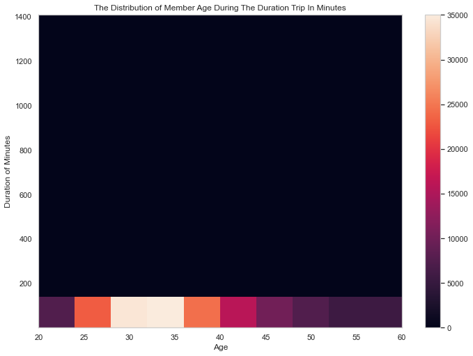

```python
# Use matplotlib.figure() function to control the default spacing of the subplots and the top level container of the subplots,
# and the top level container for all plot elements.
plt.figure(figsize=[ 11.69, 8.27]);
# Use matplotlib.pyplot.hist2d() function to make a two dimentional plot
plt.hist2d(data= df, x='member_age', y= 'duration_min');
# Use matplotlib.pyplot.colorbar () function to add a colorbar to a Plot.
plt.colorbar()
# Use matplotlib.pyplot.title() to set a title for the axes.
plt.title('The Distribution of Member Age During The Duration Trip In Minutes');
# Use matplotlib.pyplot.xlabel to set the label for the x-axis.
plt.xlabel('Age')
# Use matplotlib.pyplot.ylabel to set the label for the y-axis.
plt.ylabel('Duration of Minutes');
```

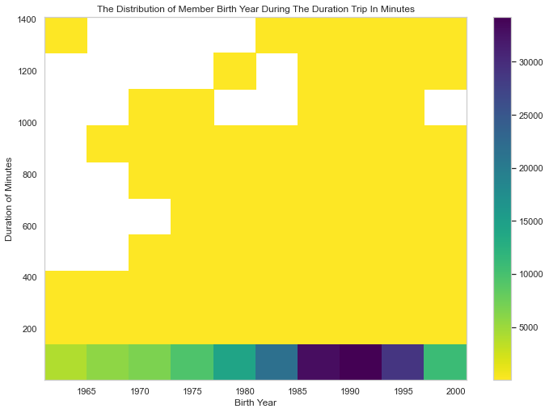

```python
plt.figure(figsize=[ 11.69, 8.27]);
# Use matplotlib.pyplot.hist2d() function to make a two dimentional plot
plt.hist2d(data= df, x='member_birth_year', y= 'duration_min', cmin=0.5, cmap='viridis_r');
plt.colorbar()
# Use matplotlib.pyplot.title() to set a title for the axes.
plt.title('The Distribution of Member Birth Year During The Duration Trip In Minutes');
plt.xlabel('Birth Year')
plt.ylabel('Duration of Minutes');
```

```python
df[['member_birth_year', 'duration_min']].describe()
```

|  | member_birth_year | duration_min |
| --- | --- | --- |
| count | 169992.000000 | 169992.000000 |
| mean | 1985.694597 | 11.717717 |
| std | 8.669889 | 27.676933 |
| min | 1961.000000 | 1.016667 |
| 25% | 1981.000000 | 5.383333 |
| 50% | 1987.000000 | 8.483333 |
| 75% | 1992.000000 | 13.100000 |
| max | 2001.000000 | 1409.133333 |

```python
# Use pandas.DataFrame.groupby() function to group dataframe using a mapper or by a Series of columns.
ct_counts = df.groupby(['user_type', 'member_gender']).size()
# Use pandas.DataFrame.reset_index() to reset the index or a level of it
ct_counts = ct_counts.reset_index(name='count')
# Use pandas.DataFrame.pivot() to rearrange dataframe organized by given index /column values
ct_counts = ct_counts.pivot(index='user_type', columns='member_gender', values='count')
ct_counts
```

| member_gender user_type | Female | Male | Other |
| --- | --- | --- | --- |
| Customer | 4535 | 11292 | 429 |
| Subscriber | 35563 | 115019 | 3154 |

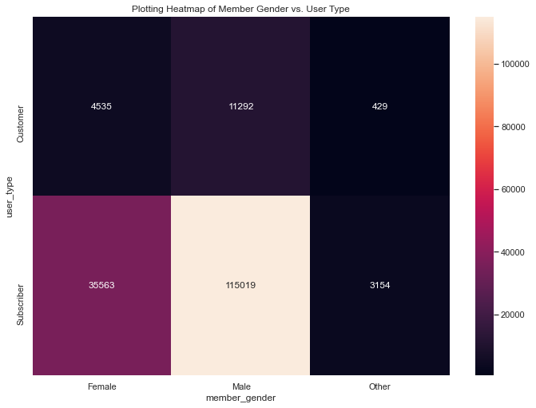

```python
# Use matplotlib.figure() function to control the default spacing of the subplots and the top level container of the subplots,
# and the top level container for all plot elements.
plt.figure(figsize=[ 11.69, 8.27]);
# Use seaborn.heatmap() function to Plot rectangular data as a color-encoded matrix.
sb.heatmap(ct_counts, annot=True, fmt='d');
plt.title('Plotting Heatmap of Member Gender vs. User Type');
```

**Resources:**

- Udacity classroom, Lesson 4: Bivariate Exploration of Data, 4.Heatmap.
- Use the documentation [Website](https://seaborn.pydata.org/generated/seaborn.heatmap.html?highlight=heatmap#seaborn.heatmap), Use **seaborn.heatmap()** function to Plot rectangular data as a color-encoded matrix.
- Use the documentation [Website](https://towardsdatascience.com/heatmap-basics-with-pythons-seaborn-fb92ea280a6c), Heatmap basics with Pythons seaborn.

**Correlation Matrix Plots**

- Heatmaps visualize the data in a 2-dimensional format in the form of colored maps. The color maps use hue, saturation, or luminance to achieve color variation to display various details. This color variation gives visual cues to the readers about the magnitude of numeric values. HeatMaps is about replacing numbers with colors because the human brain understands visuals better than numbers, text, or any written data. Human beings are visual learners; therefore, visualizing the data in any form makes more sense.
- Heatmaps can describe the density or intensity of variables, visualize patterns, variance, and even anomalies. Heatmaps show relationships between variables. These variables are plotted on both axes. We look for patterns in the cell by noticing the color change. It only accepts numeric data and plots it on the grid, displaying different data values by varying color intensity.
- A correlation matrix denotes the correlation coefficients between variables at the same time. A heat map grid can represent these coefficients to build a visual representation of the variables’ dependence. This visualization makes it easy to spot the strong dependencies. A positive correlation indicates a strong dependency, while a negative correlation indicates a strong inverse dependency; a correlation coefficient closer to zero indicates weak dependence.
- The heatmap transforms the correlation matrix into color codings. The correlation matrix shows how the variables are correlated to each other on a scale of -1 to 1. 1 being positively correlated and -1 being inversely correlated. As only numerical features can show the correlation, the heatmap cannot visualize categorical features.

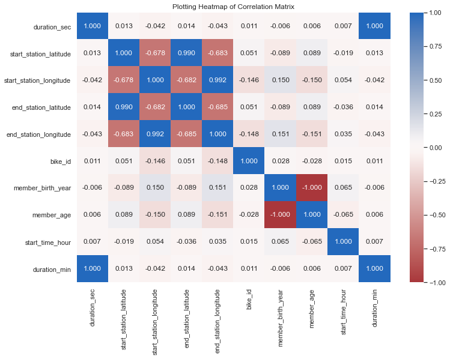

```python
# Use matplotlib.figure() function to control the default spacing of the subplots and the top level container of the subplots,
# and the top level container for all plot elements.
plt.figure(figsize=[ 11.69, 8.27]);
plt.title('Plotting Heatmap of Correlation Matrix');
# Use seaborn.heatmap() function to plot rectangular data as a color-encoded matrix.
# Use Pandas dataframe.corr() is used to find the pairwise correlation of all columns in the dataframe.
# Any na values are automatically excluded. For any non-numeric data type columns in the dataframe it is ignored.
sb.heatmap(df.corr(), annot = True, fmt = '.3f', cmap = 'vlag_r', center = 0);
```

**Observation**

- The blue color with a positive number means positive correlation between the two variables, however, the red color with minus number means negative correlation between the two variables. The stronger the color, the larger the correlation magnitude.
- Start Station Latitute has the highest positive correlation with End Station Latitude.
- Start Station Longitude has the highest positive correlation with End Station Longitude.
- Duration Minutes has the highest positive correlation with Duration Seconds.
- Start Station Latitute has the highest negative correlation with End Station Longitude, followed by Start Station Longitude.
- Start Station Longitude has the highest negative correlation with End Station Latitude, followed by Start Station Latitude.

**Bar Plots**

- A barplot is basically used to aggregate the categorical data according to some methods and by default it’s the mean. It can also be understood as a visualization of the group by action. To use this plot we choose a categorical column for the x-axis and a numerical column for the y-axis, and we see that it creates a plot taking a mean per categorical column.
- Use seaborn.barplot() method to Show point estimates and confidence intervals as rectangular bars.

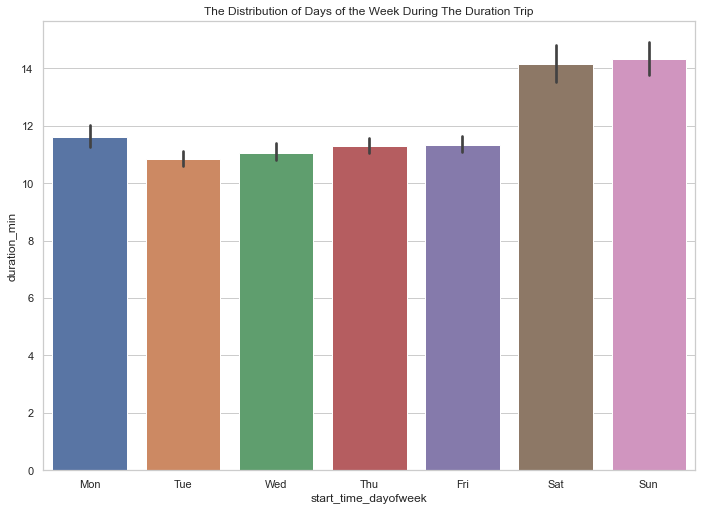

```python
# Use matplotlib.figure() function to control the default spacing of the subplots and the top level container of the subplots,
# and the top level container for all plot elements.
plt.figure(figsize=[ 11.69, 8.27]);
# Use matplotlib.pyplot.title() to set a title for the axes.
plt.title('The Distribution of Days of the Week During The Duration Trip');
# Use seaborn.barplot() method to Show point estimates and confidence intervals as rectangular bars.
sb.barplot(data=df, x= 'start_time_dayofweek', y='duration_min');
```

**Observation**

- The weekends (Saturdays and Sundays) are the highest duration trip over the days of the week.

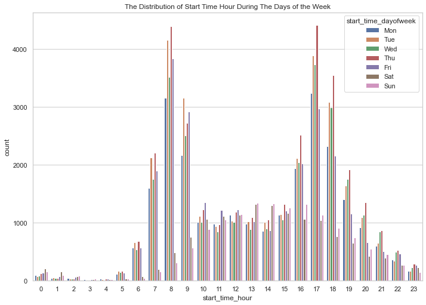

```python
# Show value counts for two categorical variables:
# Use seaborn.countplot()** function to show the counts of observations in each categorical bin using bars.
plt.figure(figsize=[ 11.69, 8.27]);
# Use matplotlib.pyplot.title() to set a title for the axes.
plt.title('The Distribution of Start Time Hour During The Days of the Week');
sb.countplot(x="start_time_hour", hue="start_time_dayofweek", data=df);
```

**Observation**

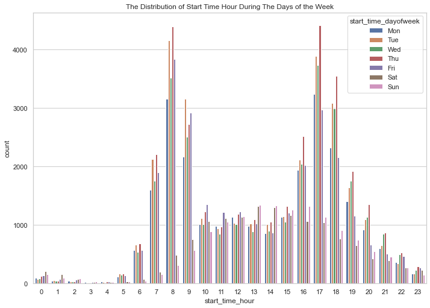

```python
plt.figure(figsize=[ 11.69, 8.27]);
# Use matplotlib.pyplot.title() to set a title for the axes.
plt.title('The Distribution of Start Time Hour During The Days of the Week');
sb.countplot(data = df, x = 'start_time_hour', hue = 'start_time_dayofweek');
```

**Observation**

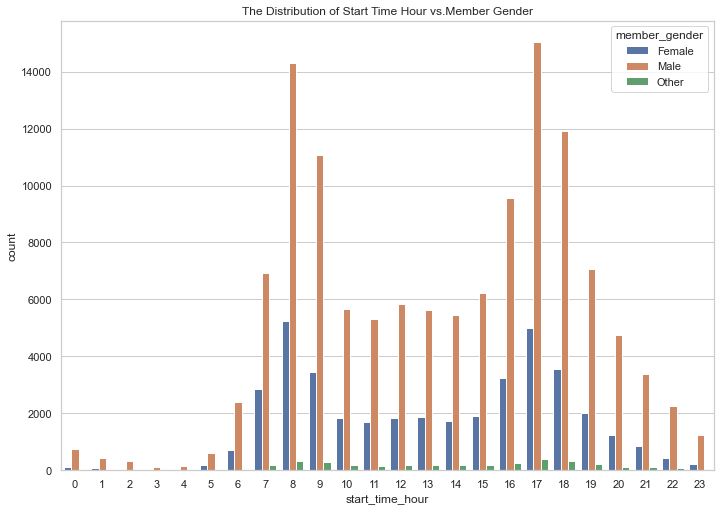

```python
plt.figure(figsize=[ 11.69, 8.27]);
# Use matplotlib.pyplot.title() to set a title for the axes.
plt.title('The Distribution of Start Time Hour vs.Member Gender');
sb.countplot(data = df, x = 'start_time_hour', hue = 'member_gender');
```

**Observation**

- An 8:00 AM and 5:00 PM have the highest across the seven days, and twenty-four hours.
- The male has the highest biker counts over the female, especially during the 8:00 AM and 5:00 PM.

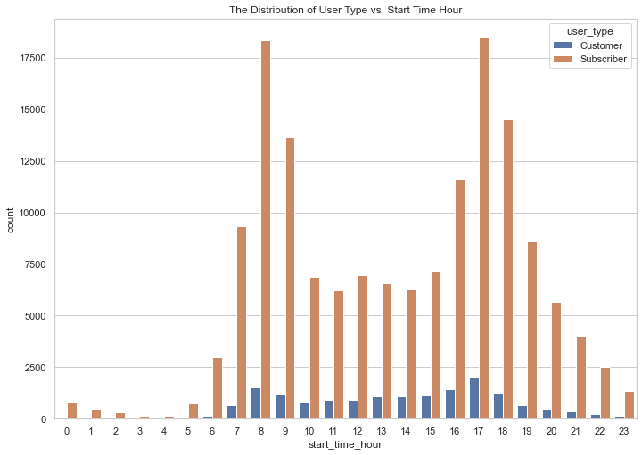

```python
plt.figure(figsize=[ 11.69, 8.27]);
# Use matplotlib.pyplot.title() to set a title for the axes.
plt.title('The Distribution of User Type vs. Start Time Hour');
sb.countplot(data = df, x = 'start_time_hour', hue = 'user_type');
```

**Observation**

- An 8:00 AM and 5:00 PM have the highest across the seven days, and twenty-four hours.
- The subscriber has the highest biker counts over the customer across the seven days, and twenty-four hours.

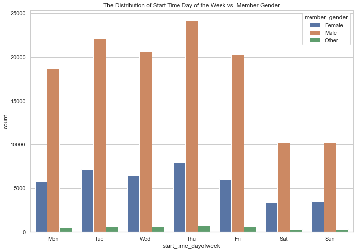

```python
plt.figure(figsize=[ 11.69, 8.27]);
# Use matplotlib.pyplot.title() to set a title for the axes.
plt.title('The Distribution of Start Time Day of the Week vs. Member Gender');
sb.countplot(data = df, x = 'start_time_dayofweek', hue = 'member_gender');
```

**Observation**

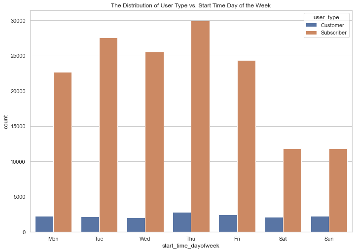

```python
plt.figure(figsize=[ 11.69, 8.27]);
# Use matplotlib.pyplot.title() to set a title for the axes.
plt.title('The Distribution of User Type vs. Start Time Day of the Week');
sb.countplot(data = df, x = 'start_time_dayofweek', hue = 'user_type');
```

**Observation**

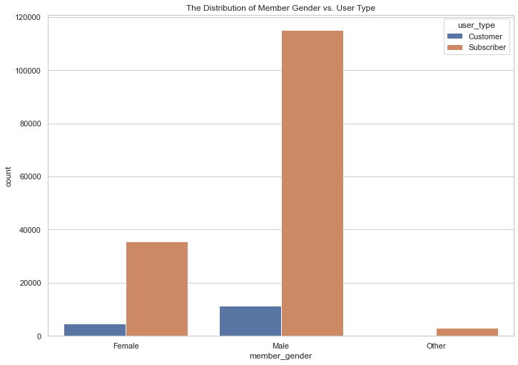

```python
plt.figure(figsize=[ 11.69, 8.27]);
# Use matplotlib.pyplot.title() to set a title for the axes.
plt.title('The Distribution of Member Gender vs. User Type');
sb.countplot(data = df, x = 'member_gender', hue = 'user_type');
```

**Observation**

- Most 'Customer' and 'Subscribers' bikers are male.
- Most male are subcriber rather than customer.

**Violin Plots**

There are a few ways of plotting the relationship between one quantitative and one qualitative variable, that demonstrate the data at different levels of abstraction. The violin plot is on the lower level of abstraction. For each level of the categorical variable, a distribution of the values on the numeric variable is plotted. The distribution is plotted as a kernel density estimate, something like a smoothed histogram. There is an extra section at the end of the previous lesson that provides more insight into kernel density estimates.

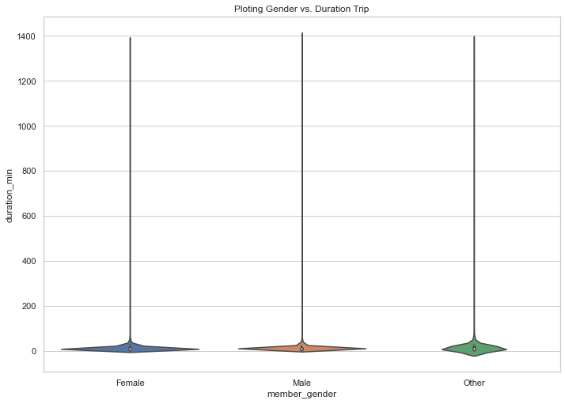

```python
plt.figure(figsize=[ 11.69, 8.27])
plt.title('Ploting Gender vs. Duration Trip')
# Use seaborn.violinplot() function to draw a combination of boxplot and kernel density estimate.
sb.violinplot(data=df, x='member_gender', y='duration_min');
```

**Observation**

The previous figure reveal the trip duration (in minutes) in all member gender (female, male, and other)

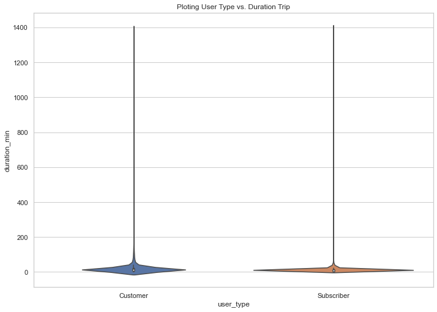

```python
plt.figure(figsize=[ 11.69, 8.27]);
plt.title('Ploting User Type vs. Duration Trip');
# Use seaborn.violinplot() function to draw a combination of boxplot and kernel density estimate.
sb.violinplot(data=df, x='user_type', y='duration_min');
```

**Observation**

The previous figure reveal the trip duration (in minutes) in all user type (customer, and Subscriber)

```python
df['start_time_dayofweek']
```

```
0         Thu
2         Thu
3         Thu
4         Thu
6         Thu
         ...
183407    Fri
183408    Fri
183409    Fri
183410    Fri
183411    Fri
Name: start_time_dayofweek, Length: 169992, dtype: category
Categories (7, object): ['Mon' < 'Tue' < 'Wed' < 'Thu' < 'Fri' < 'Sat' < 'Sun']
```

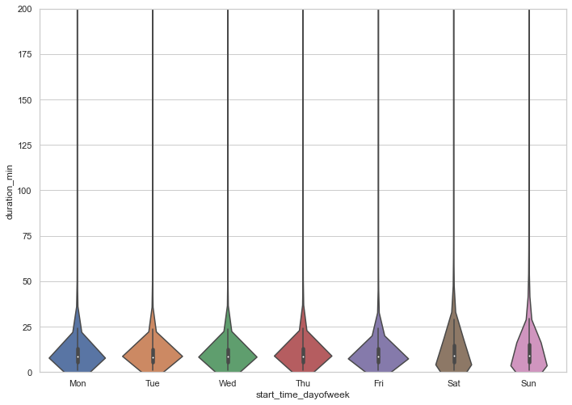

```python
# Duration during the days of week
day_of_week = ['Mon', 'Tue', 'Wed', 'Thu', 'Fri', 'Sat', 'Sun']

# Refer - https://pandas.pydata.org/pandas-docs/version/0.23.4/generated/pandas.api.types.CategoricalDtype.html
weekday = pd.api.types.CategoricalDtype(ordered=True, categories=day_of_week)

# Use pandas.astype() to convert the "start_time_dayofweek" column from a plain object type into an ordered categorical type
df['start_time_dayofweek'] = df['start_time_dayofweek'].astype(weekday);

plt.figure(figsize=[ 11.69, 8.27]);
plt.ylim([0,200]);

sb.violinplot(data=df, x='start_time_dayofweek', y='duration_min');
```

**Observation**

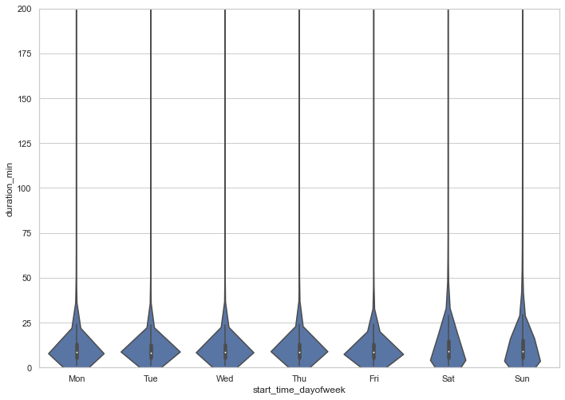

```python
base_color = sb.color_palette()[0]

plt.figure(figsize=[ 11.69, 8.27]);
plt.ylim([0,200]);

# The "inner" argument represents the datapoints in the violin interior.
# It can take any value from {“box”, “quartile”, “point”, “stick”, None}
# If "box", it draws a miniature boxplot.
sb.violinplot(data=df, x='start_time_dayofweek', y='duration_min', color=base_color, innner=None);
```

**Observation**

```python
df['user_type'].value_counts(), df['user_type'].value_counts(normalize=True)
```

```
(Subscriber    153736
 Customer       16256
 Name: user_type, dtype: int64,
 Subscriber    0.904372
 Customer      0.095628
 Name: user_type, dtype: float64)
```

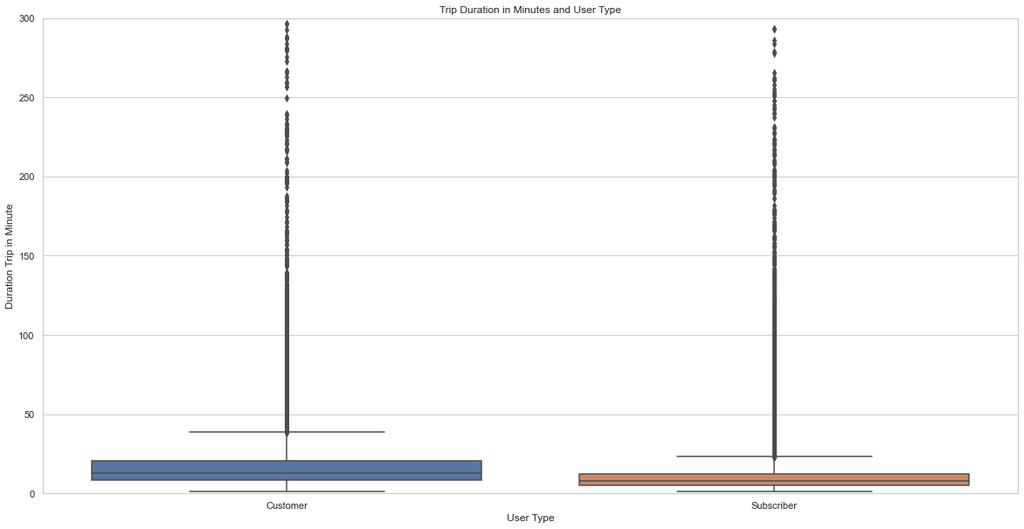

```python
# Use matplotlib.figure() function to control the default spacing of the subplots and the top level container of the subplots,
# and the top level container for all plot elements.
plt.figure(figsize = [20, 10])
# Use seaborn.boxplot() function to draw a box plot to show distributions with respect to categories.
sb.boxplot(data=df, x='user_type', y='duration_min');
# Use matplotlib.pyplot.xlim() function to get or set the x limits of the current axes.
plt.ylim([0, 300])
# Use matplotlib.pyplot.title() to set a title for the axes.
plt.title('Trip Duration in Minutes and User Type')
# Use matplotlib.pyplot.xlabel to set the label for the x-axis.
plt.xlabel('User Type')
# Use matplotlib.pyplot.ylabel to set the label for the y-axis.
plt.ylabel('Duration Trip in Minute')
# Use matplotlib.show() function to display all open figures.
plt.show();
```

**Observation**

- The higher percentage of customer rides longer trips than subscriber although number of subscriber riders are higher than customer.
- However, the value counts of "Subscriber" is 153,736 of the total "User Type", and the value counts of "Customer" is 16,256 of total "User Type". Furthermore, the percentage of "Subscriber" is representing approximately 90% of "User Type" and the "Customer" is representing approximately 10% of "User Type.

**Faceting**

- The Faceted plot is a multiple copies of the same type of plot visualized on different subsets of the data.
- One general visualization technique that will be useful for you to know about to handle plots of two or more variables is faceting. In faceting, the data is divided into disjoint subsets, most often by different levels of a categorical variable. For each of these subsets of the data, the same plot type is rendered on other variables.
- Faceting is a way of comparing distributions or relationships across levels of additional variables, especially when there are three or more variables of interest overall. While faceting is most useful in multivariate visualization, it is still valuable to introduce the technique here in our discussion of bivariate plots.
- FacetGrid class helps in visualizing distribution of one variable as well as the relationship between multiple variables separately within subsets of your dataset using multiple panels.
- A FacetGrid can be drawn with up to three dimensions ? row, col, and hue. The first two have obvious correspondence with the resulting array of axes; think of the hue variable as a third dimension along a depth axis, where different levels are plotted with different colors.
- FacetGrid object takes a dataframe as input and the names of the variables that will form the row, column, or hue dimensions of the grid. The variables should be categorical and the data at each level of the variable will be used for a facet along that axis.

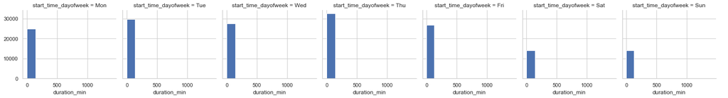

```python
# Trip Duration during the days of week
# Convert the "start_time_dayofweek" column from a plain object type into an ordered categorical type
day_of_week = ['Mon', 'Tue', 'Wed', 'Thu', 'Fri', 'Sat', 'Sun']

# Refer - https://pandas.pydata.org/pandas-docs/version/0.23.4/generated/pandas.api.types.CategoricalDtype.html
weekday = pd.api.types.CategoricalDtype(ordered=True, categories=day_of_week)

# Use pandas.astype() to convert the "start_time_dayofweek" column from a plain object type into an ordered categorical type
df['start_time_dayofweek'] = df['start_time_dayofweek'].astype(weekday);

# Plot the Seaborn's FacetGrid
g = sb.FacetGrid(data = df, col = 'start_time_dayofweek')
g.map(plt.hist, "duration_min");
g.add_legend();
```

**Observation**

```python
df['duration_min'].describe()
```

```
count    169992.000000
mean         11.717717
std          27.676933
min           1.016667
25%           5.383333
50%           8.483333
75%          13.100000
max        1409.133333
Name: duration_min, dtype: float64
```

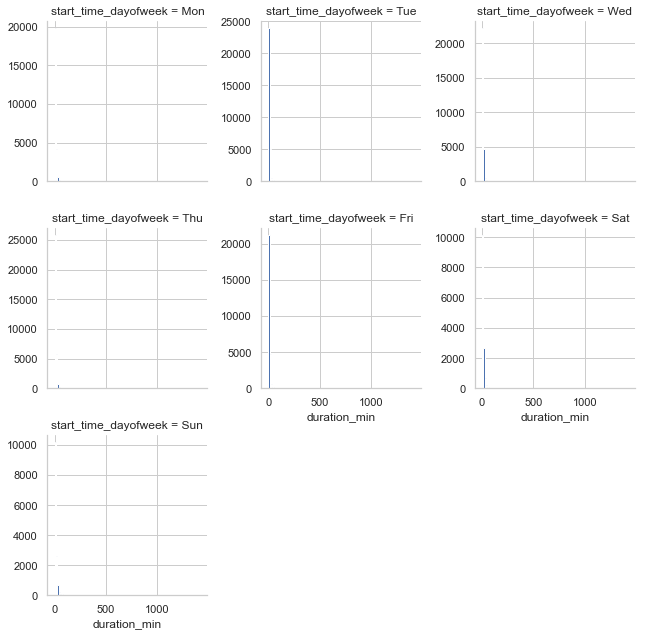

```python
bin_edges = np.arange(1, 1409+13,13)

# Try experimenting with dynamic bin edges

g = sb.FacetGrid(data = df, col = 'start_time_dayofweek', col_wrap=3, sharey=False)
g.map(plt.hist, 'duration_min', bins = bin_edges);
g.add_legend();
```

**Observation**

**Resources:**

- Udacity classroom, Lesson 4: Bivariate Exploration of Data, 11.Faceting.
- Use the documentation [Website](https://seaborn.pydata.org/generated/seaborn.FacetGrid.html), Use **seaborn.FacetGrid()** method to Multi-plot grid for plotting conditional relationships.
- Use the documentation [Website](https://www.geeksforgeeks.org/python-seaborn-facetgrid-method/), Python – **seaborn.FacetGrid() method**.

**Conclusion**

**Talk about some of the relationships you observed in this part of the investigation. How did the feature(s) of interest vary with other features in the dataset?**

**Did you observe any interesting relationships between the other features (not the main feature(s) of interest)?**

I thought that variables which are user type and gender values having higher value to get higher trip duration but it is the opposite. For gender, value of male members is very high but it got lower trip duration. For user type, value of subscriber members is very high but it got lower trip duration then customer.

### Multivariate Exploration

**There are four major cases to consider when we want to plot three variables together:**

- three numeric variables
- two numeric variables and one categorical variable
- one numeric variable and two categorical variables
- three categorical variables

**Encoding via Size**

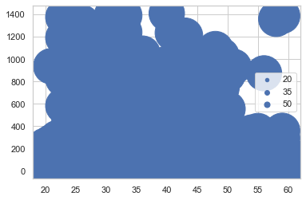

```python
# Encoding via Size
# Use matplotlib.pyplot.scatter() function to apply a scatter plot of y vs. x with varying marker size and /or color
plt.scatter(data = df, x = 'member_age', y = 'duration_min', s = 'member_birth_year')

# dummy series for adding legend
sizes = [20, 35, 50]
base_color = sb.color_palette()[0]
legend_obj = []
for s in sizes:
    legend_obj.append(plt.scatter([], [], s = s, color = base_color))
plt.legend(legend_obj, sizes)
```

**Observation**

- The data points are just all over the place.

**Resources:**

- Udacity classroom, Lesson 5: Multivariate Exploration of Data, 2.Non-Positional Encoding For Third Variables.

**Faceting for Multivariate Data**

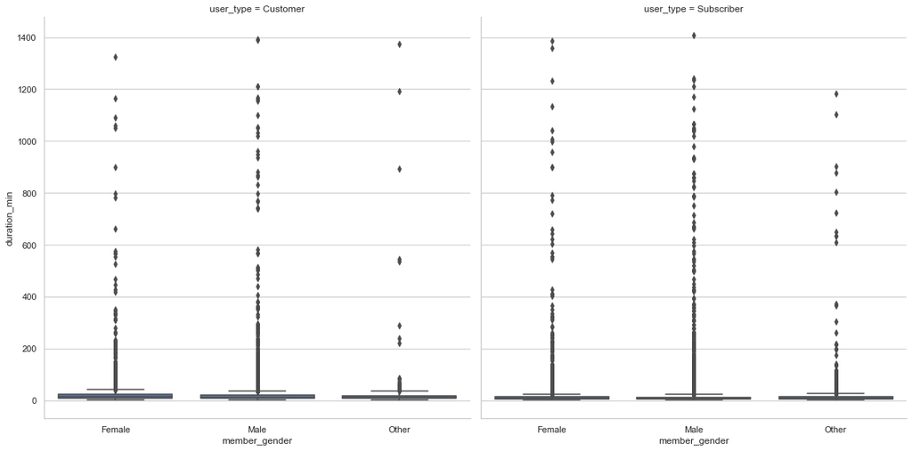

```python
g = sb.FacetGrid(data = df, col = 'user_type', size = 8)
g.map(sb.boxplot, 'member_gender', 'duration_min')
```

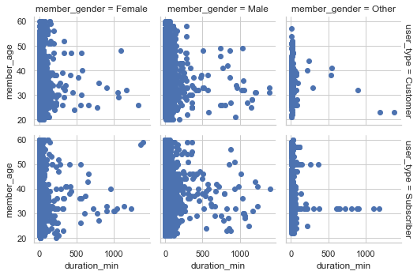

```python
g = sb.FacetGrid(data = df, col = 'member_gender', row = 'user_type', size = 2.5,margin_titles = True)
g.map(plt.scatter, 'duration_min', 'member_age');
```

**Resources:**

- Udacity classroom, Lesson 5: Multivariate Exploration of Data, 5.Faceting in Two Directions.

**Plot Matrices**

By default, PairGrid only expects to depict numeric variables; a typical invocation of PairGrid plots the same variables on the horizontal and vertical axes. On the diagonals, where the row and column variables match, a histogram is plotted. Off the diagonals, a scatterplot between the two variables is created.

Use seaborn.PairGrid() functionSubplot grid for plotting pairwise relationships in a dataset.

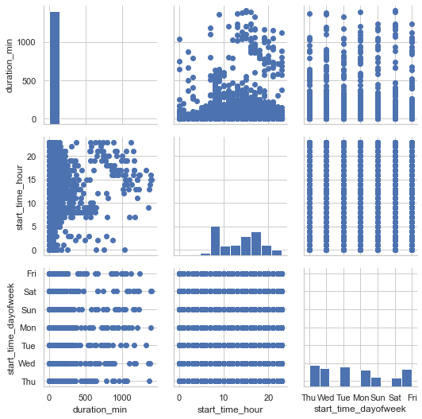

```python
g = sb.PairGrid(data = df, vars = ['duration_min', 'start_time_hour', 'start_time_dayofweek'])
g.map_diag(plt.hist)
g.map_offdiag(plt.scatter)
```

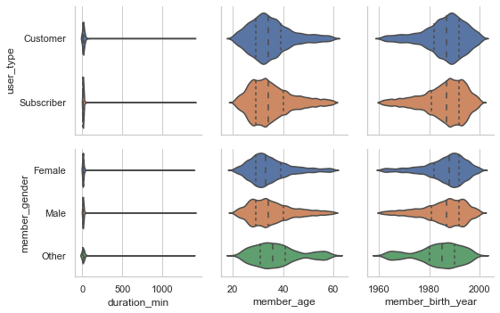

```python
g = sb.PairGrid(data = df, x_vars = ['duration_min', 'member_age', 'member_birth_year'],
                y_vars = ['user_type','member_gender'])
g.map(sb.violinplot, inner = 'quartile')
```

**Correlation Matrices**

For numeric variables, it can be useful to create a correlation matrix as part of your exploration. While it's true that the .corr function is perfectly fine for computing and returning a matrix of correlation coefficients, it's not too much trouble to plot the matrix as a heat map to make it easier to see the strength of the relationships.

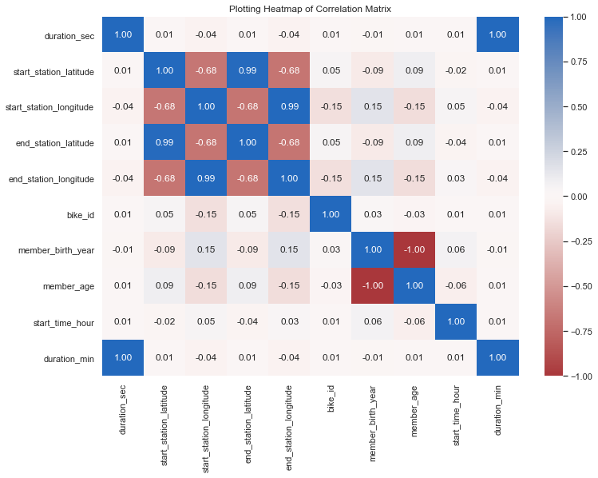

```python
# Use matplotlib.figure() function to control the default spacing of the subplots and the top level container of the subplots,
# and the top level container for all plot elements.
plt.figure(figsize=[ 11.69, 8.27]);
plt.title('Plotting Heatmap of Correlation Matrix');
sb.heatmap(df.corr(), annot = True, fmt = '.2f', cmap = 'vlag_r', center = 0);
```

**Observation**

- The blue color with a positive number means positive correlation between the two variables, however, the red color with minus number means negative correlation between the two variables. The stronger the color, the larger the correlation magnitude.
- Start Station Latitute has the highest positive correlation with End Station Latitude.
- Start Station Longitude has the highest positive correlation with End Station Longitude.
- Duration Minutes has the highest positive correlation with Duration Seconds.
- Start Station Latitute has the highest negative correlation with End Station Longitude, followed by Start Station Longitude.
- Start Station Longitude has the highest negative correlation with End Station Latitude, followed by Start Station Latitude.

**Resources:**

- Udacity classroom, Lesson 5: Multivariate Exploration of Data, 8.Plot Matrices.

#### Conclusion

**Talk about some of the relationships you observed in this part of the investigation. Were there features that strengthened each other in terms of looking at your feature(s) of interest?**

- There is no strong relationship among The features I investigated.

**Were there any interesting or surprising interactions between features?**

- Most 'Customer' and 'Subscribers' bikers are male.
- An 8:00 AM and 5:00 PM have the highest customer and sunscriber bikers across seven days, twenty-four hours.
- Thursday has the most 'Subscriber' and 'Customer' bikers compare to other days.
- There are more younger bikers (age < 40) across 7 days and 24 hours.

**Summary of findings:**